# W3cubDocs

## Revoking an organization invitation

As an organization owner, if you've made a mistake in inviting someone to your organization, you can revoke the organization invitation.

1. [Log in](https://www.npmjs.com/login) to npm with your user account.

2. In the upper right corner of the page, click your profile picture, then click **Account**.

3. In the left sidebar, click the name of your organization.

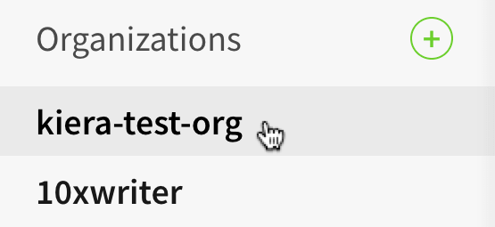

4. On the organization settings page, click **Members**.

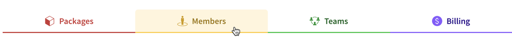

5. Click the **Invite Members** button.

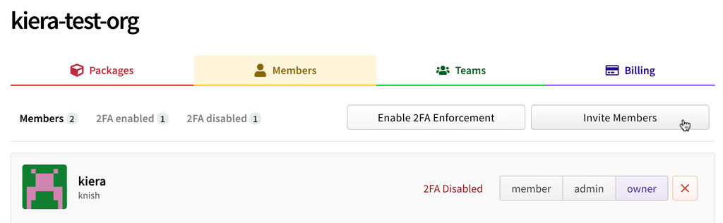

6. Under the "Invitations" field, click the **X** next to the name of the user invitation you would like to revoke.

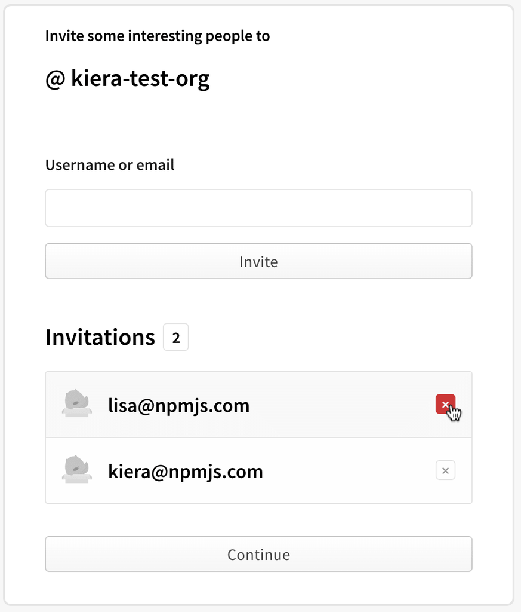